# Pokemon

Aman

20/02/2021

```r
getwd()
```

```
## [1] "D:/IISER BHOPAL/SEM 8/DSE 401/Revision"
```

# Exploring Pokemon dataset:

#### Finding more details about our dataset:

- Correlations
- Normality tests
- some intersting patterns

#### Finding patterns:

I’ll be dealing with following Hypothesises

- *Hypothesis1:* legenaday pokemons are better ?
- *Hypothesis2:* normality check of height , defence and attack
- *Hypothesis3:* hypothesis small pokemon has greater speed ?
- *Hypothesis4:* Do Pokemons improve with generations?
- *Hypothesis5:* Is Bigger the better, always?

## Loading the libraries

```r
library(tidyverse)
library(dplyr)
library(tidyr)
library(Hmisc)
library(ggplot2)
```

# Goal: Using R explore the pokemon dataset

## Importing dataset

```r
pokemon <- read.csv("pokemon.csv", header = T)
```

```r
dim(pokemon)
```

```
## [1] 801  41
```

This pokemon dataset has 801 rows and 41 cols

```r
head(pokemon)
```

```
##                     abilities against_bug against_dark against_dragon
## 1 ['Overgrow', 'Chlorophyll']        1.00            1              1
## 2 ['Overgrow', 'Chlorophyll']        1.00            1              1
## 3 ['Overgrow', 'Chlorophyll']        1.00            1              1
## 4    ['Blaze', 'Solar Power']        0.50            1              1
## 5    ['Blaze', 'Solar Power']        0.50            1              1
## 6    ['Blaze', 'Solar Power']        0.25            1              1
##   against_electric against_fairy against_fight against_fire against_flying
## 1              0.5           0.5           0.5          2.0              2
## 2              0.5           0.5           0.5          2.0              2
## 3              0.5           0.5           0.5          2.0              2
## 4              1.0           0.5           1.0          0.5              1
## 5              1.0           0.5           1.0          0.5              1
## 6              2.0           0.5           0.5          0.5              1
##   against_ghost against_grass against_ground against_ice against_normal
```

[output cut: 41 more lines]

```r
str(pokemon)
```

```
## 'data.frame':    801 obs. of  41 variables:
##  $ abilities        : chr  "['Overgrow', 'Chlorophyll']" "['Overgrow', 'Chlorophyll']" "['Overgrow', 'Chlorophyll']" "['Blaze', 'Solar Power']" ...
##  $ against_bug      : num  1 1 1 0.5 0.5 0.25 1 1 1 1 ...
##  $ against_dark     : num  1 1 1 1 1 1 1 1 1 1 ...
##  $ against_dragon   : num  1 1 1 1 1 1 1 1 1 1 ...
##  $ against_electric : num  0.5 0.5 0.5 1 1 2 2 2 2 1 ...
##  $ against_fairy    : num  0.5 0.5 0.5 0.5 0.5 0.5 1 1 1 1 ...
##  $ against_fight    : num  0.5 0.5 0.5 1 1 0.5 1 1 1 0.5 ...
##  $ against_fire     : num  2 2 2 0.5 0.5 0.5 0.5 0.5 0.5 2 ...
##  $ against_flying   : num  2 2 2 1 1 1 1 1 1 2 ...
##  $ against_ghost    : num  1 1 1 1 1 1 1 1 1 1 ...
##  $ against_grass    : num  0.25 0.25 0.25 0.5 0.5 0.25 2 2 2 0.5 ...
##  $ against_ground   : num  1 1 1 2 2 0 1 1 1 0.5 ...
##  $ against_ice      : num  2 2 2 0.5 0.5 1 0.5 0.5 0.5 1 ...
##  $ against_normal   : num  1 1 1 1 1 1 1 1 1 1 ...
```

[output cut: 27 more lines]

# distribution of pokemon based on type 1

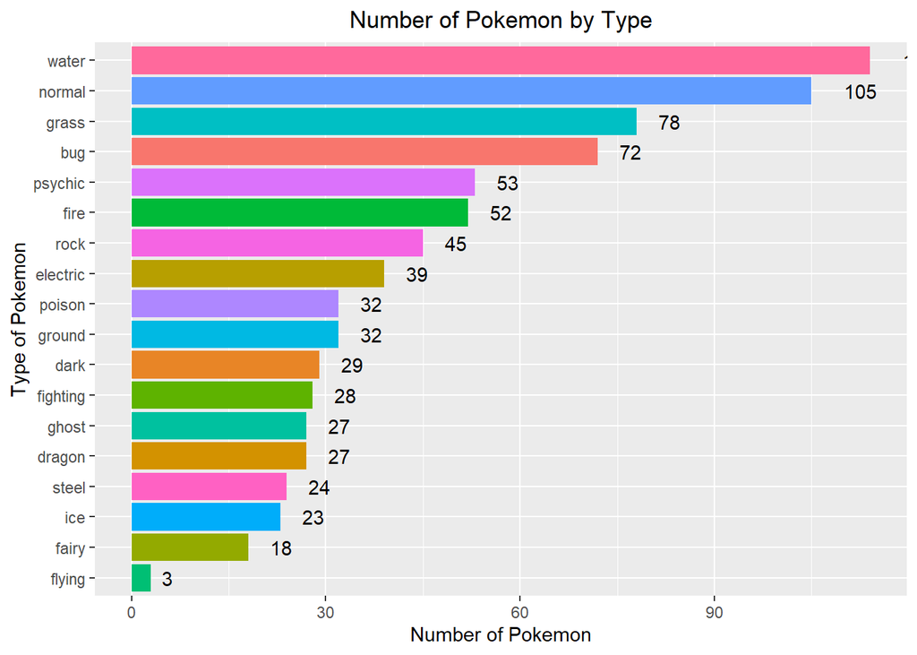

```r
pokemon %>%
  group_by(type1) %>%
  summarise(number = n()) %>%
  ggplot(aes(x = reorder(type1, number), y = number , fill = type1)) +
  geom_bar(stat = 'identity') +
  xlab(label = "Type of Pokemon") +
  ylab(label = "Number of Pokemon") +
  ggtitle(label = "Number of Pokemon by Type") +
  theme(plot.title = element_text(hjust = 0.5)) +
  theme(legend.position="none") +
  coord_flip() +
  geom_text(aes(label = number), hjust = -1.0)
```

# distribution of pokemon based on type 2

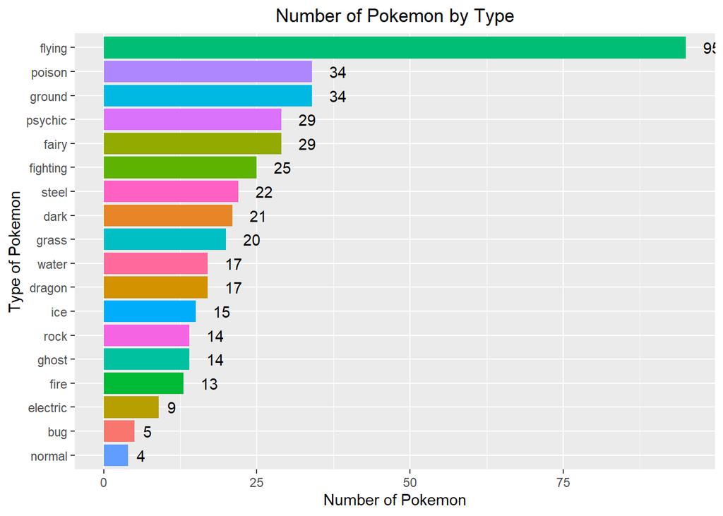

```r
pokemon %>%
  filter(type2 != '') %>%
  group_by(type2) %>%
  summarise(number = n()) %>%
  ggplot(aes(x = reorder(type2, number), y = number , fill = type2)) +
  geom_bar(stat = 'identity') +
  xlab(label = "Type of Pokemon") +
  ylab(label = "Number of Pokemon") +
  ggtitle(label = "Number of Pokemon by Type") +
  theme(plot.title = element_text(hjust = 0.5)) +
  theme(legend.position="none") +
  coord_flip() +
  geom_text(aes(label = number), hjust = -1.0)
```

## subset of numeric columns

```r
#install.packages("dplyr")
```

# Subseting the numeric columns

```r
library(dplyr)
num_pokemon <- select_if(pokemon, is.numeric)
dim(num_pokemon)
```

```
## [1] 801  34
```

# subset pokemon with generation

```r
generation1<- pokemon[pokemon$generation== 1,]
generation2<- pokemon[pokemon$generation== 2,]
generation3<- pokemon[pokemon$generation== 3,]
generation4<- pokemon[pokemon$generation== 4,]
generation5<- pokemon[pokemon$generation== 5,]
generation6<- pokemon[pokemon$generation== 6,]
generation7<- pokemon[pokemon$generation== 7,]
```

# Creating subset of legendary and non legendary pokemons

```r
is_legendary<- pokemon[pokemon$is_legendary==1, ]
not_legendary<- pokemon[pokemon$is_legendary==0, ]
#conveted to data frame
legendary <- data.frame(
 Type = c("Legendary", "Not Legendary"),
 Numbers = c(nrow(is_legendary), nrow(not_legendary))
 )
```

## Pie chat to visualise the pokemon based on legendary (ggplot)

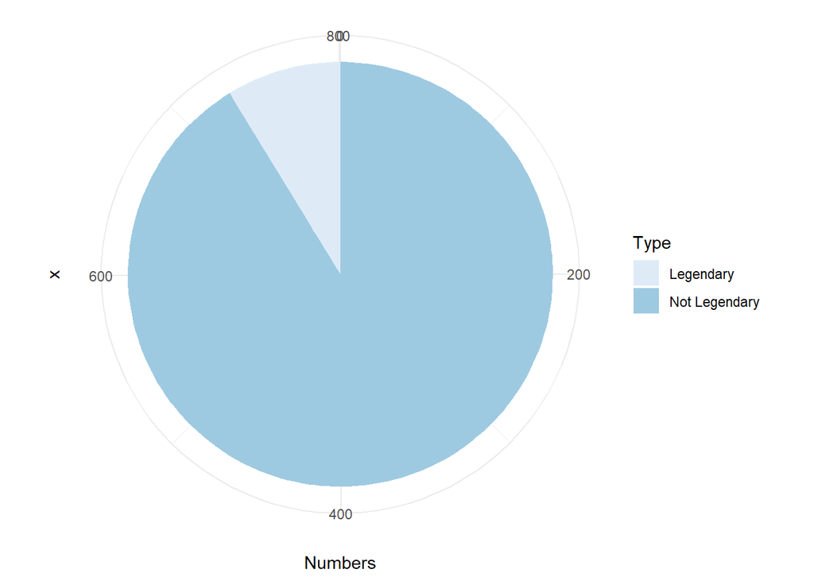

```r
ggplot(legendary, aes(x="", y= Numbers, fill= Type))+
  geom_bar(width = 1, stat = "identity")+
  coord_polar("y", start=0)+
  scale_fill_brewer(palette="Blues")+
  theme_minimal()
```

## Pie chat to visualise the pokemon based on generation

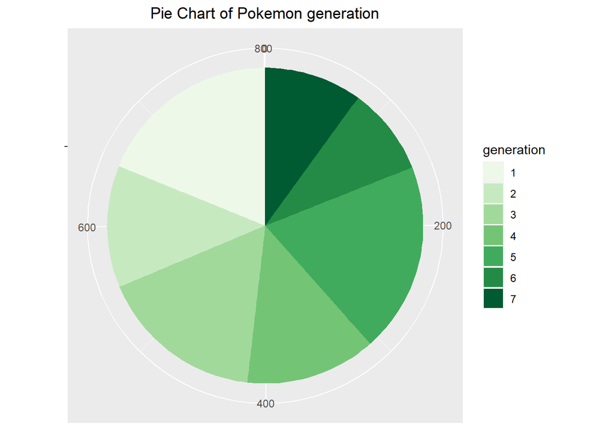

```r
pie <- ggplot(pokemon, aes(x = "", fill = factor(generation))) +
  geom_bar(width = 1) +
  theme(axis.line = element_blank(),
        plot.title = element_text(hjust=0.5)) +
  labs(fill="generation",
       x=NULL,
       y=NULL,
       title="Pie Chart of Pokemon generation")

pie + coord_polar(theta = "y") + scale_fill_brewer(palette = "Green")
```

## Density plot to visualise height of the pokemon based on generation

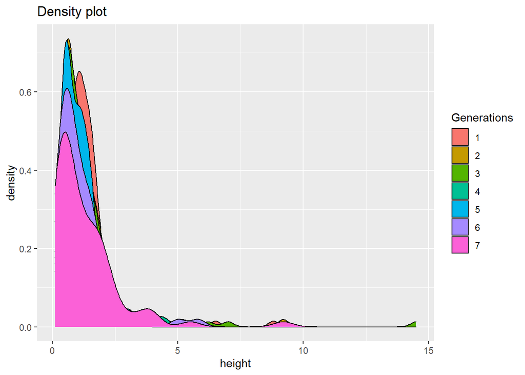

```r
g <- ggplot(pokemon, aes(height_m))
g + geom_density(aes(fill=factor(generation))) +
    labs(title="Density plot",
         x="height",
         fill="Generations")
```

## Density plot to visualise attack of the pokemon based on generation

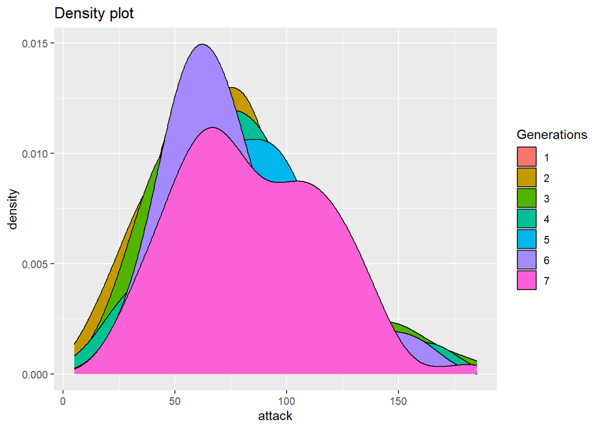

```r
g <- ggplot(pokemon, aes(attack))
g + geom_density(aes(fill=factor(generation))) +
    labs(title="Density plot",
         x="attack",
         fill="Generations")
```

## Density plot to visualise base happiness offthe pokemon based on generation

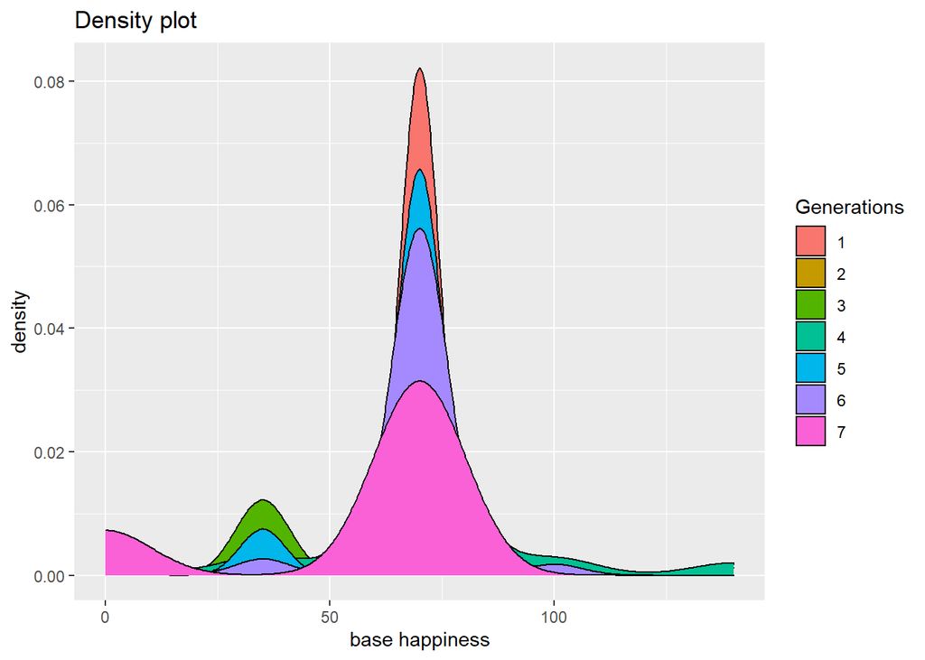

```r
g <- ggplot(pokemon, aes(base_happiness))
g + geom_density(aes(fill=factor(generation))) +
    labs(title="Density plot",
         x="base happiness",
         fill="Generations")
```

```r
library(gridExtra)
library(grid)
```

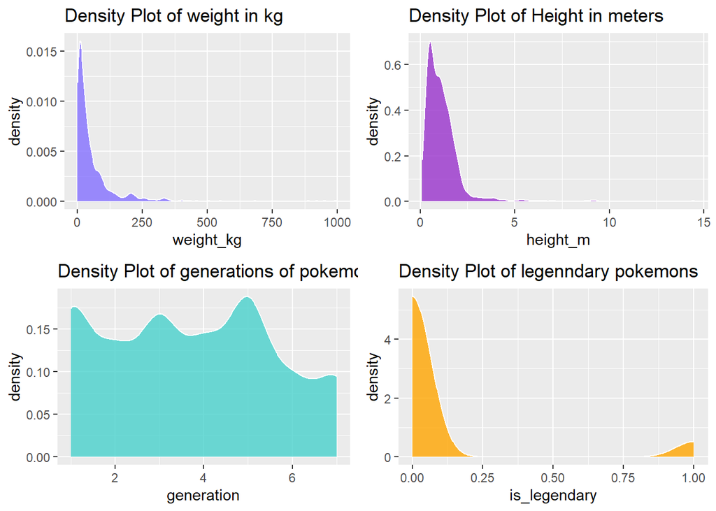

```r
density_weight <- ggplot(data=pokemon, aes(weight_kg)) + geom_density(col="white",fill="slateblue1", alpha=0.8) + ggtitle("Density Plot of weight in kg")
density_height <- ggplot(data=pokemon, aes(height_m)) + geom_density(col="white",fill="darkorchid", alpha=0.8) + ggtitle("Density Plot of Height in meters")
density_generation <- ggplot(data=pokemon, aes(generation)) + geom_density(col="white",fill="mediumturquoise", alpha=0.8) + ggtitle("Density Plot of generations of pokemons")
density_legendary <- ggplot(data=pokemon, aes(is_legendary)) + geom_density(col="white",fill="orange", alpha=0.8) + ggtitle("Density Plot of legenndary pokemons")
grid.arrange(density_weight, density_height, density_generation, density_legendary)
```

```r
#install.packages("plotrix")
```

# Subset dataset into 3 categories based on height

```r
small <- na.omit(num_pokemon[num_pokemon$height_m <=0.7, ])
mid <- na.omit(num_pokemon[num_pokemon$height_m >0.7 & pokemon$height_m <=1.4, ])
big <- na.omit(num_pokemon[num_pokemon$height_m >1.4, ])
```

# normality check of hieght of pokemon

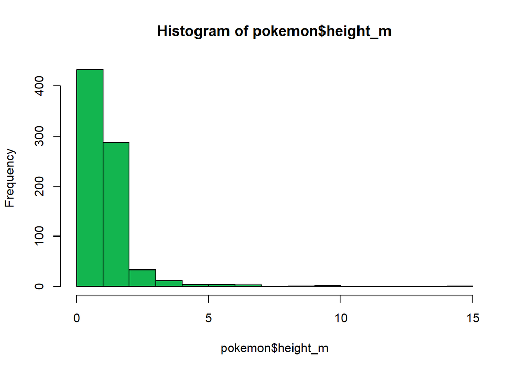

```r
hist(pokemon$height_m, col = "#13b54f")
```

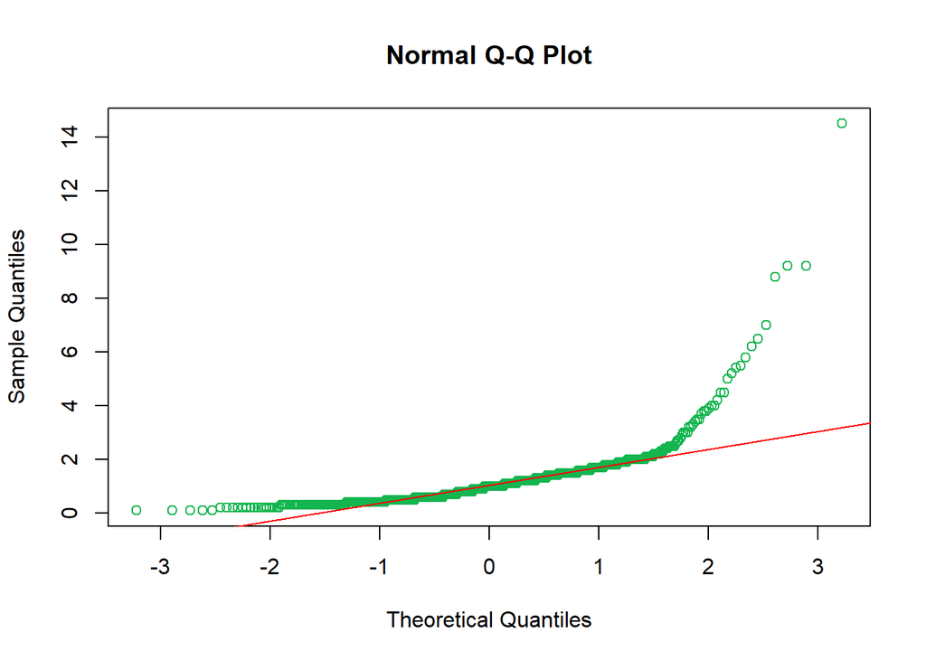

```r
#quntile quantile plot
qqnorm(pokemon$height_m, col = "#13b54f")
#qqline for normal distribution
qqline(pokemon$height_m,col='red')
```

### Checking normality

First we will perform **Shapiro-Wilk Normality Test** to check whether the height of the pokemon has normal distribution.

- Null Hypothesis, $H_0 :=$ height is normally distributed
- Alternate Hypothesis, $H_a :=$ height is **NOT** normally distributed

```r
#normaltiy test
shapiro.test(pokemon$height_m)
```

```
##
##  Shapiro-Wilk normality test
##
## data:  pokemon$height_m
## W = 0.62103, p-value < 2.2e-16
```

p value is soo low , so we can reject null hypothesis , hence distribution is not normal

### Checking normality for defence of pokemon

- Null Hypothesis, $H_0 :=$ defense is normally distributed
- Alternate Hypothesis, $H_a :=$ defense is **NOT** normally distributed

```r
shapiro.test(pokemon$defense)
```

```
##
##  Shapiro-Wilk normality test
##
## data:  pokemon$defense
## W = 0.93984, p-value < 2.2e-16
```

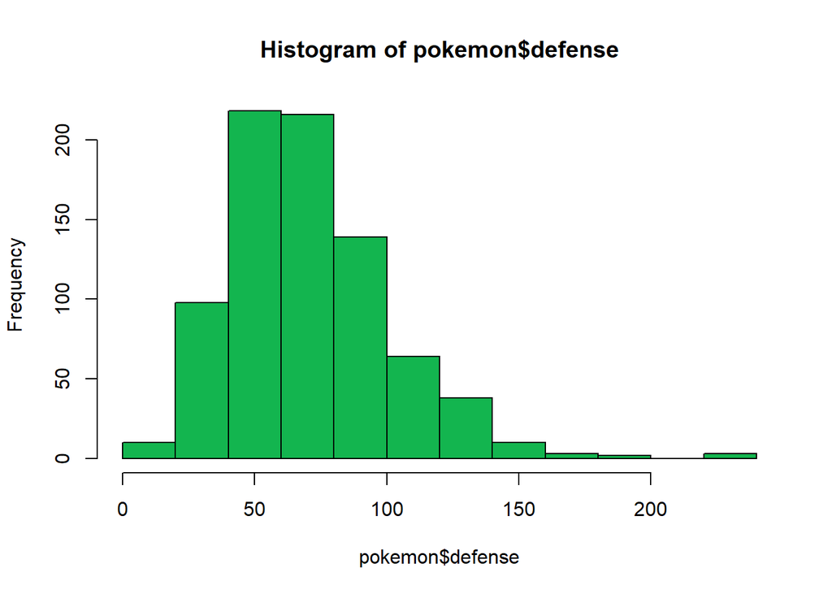

```r
hist(pokemon$defense, col = "#13b54f")
```

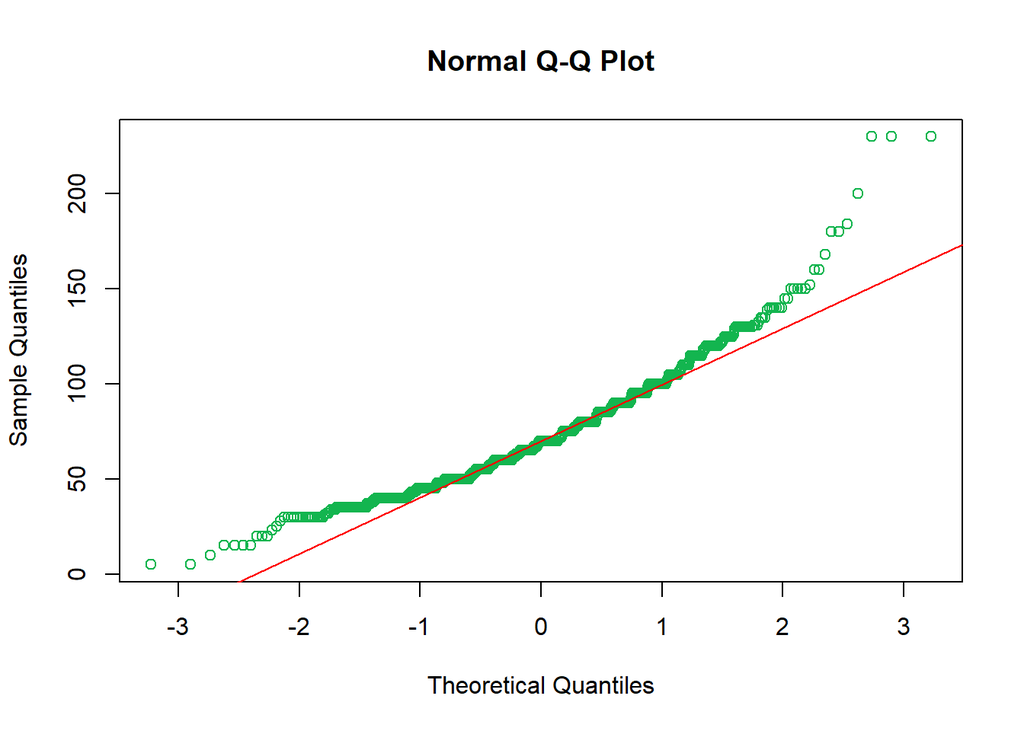

```r
#quntile quantile plot
qqnorm(pokemon$defense, col = "#13b54f")
#qqline for normal distribution
qqline(pokemon$defense,col='red')
```

### Checking normality for attack of pokemon

First we will perform **Shapiro-Wilk Normality Test** to check whether the attack of the pokemon has normal distribution.

- Null Hypothesis, $H_0 :=$ attack is normally distributed
- Alternate Hypothesis, $H_a :=$ attack is **NOT** normally distributed

```r
shapiro.test(pokemon$attack)
```

```
##
##  Shapiro-Wilk normality test
##
## data:  pokemon$attack
## W = 0.97948, p-value = 3.581e-09
```

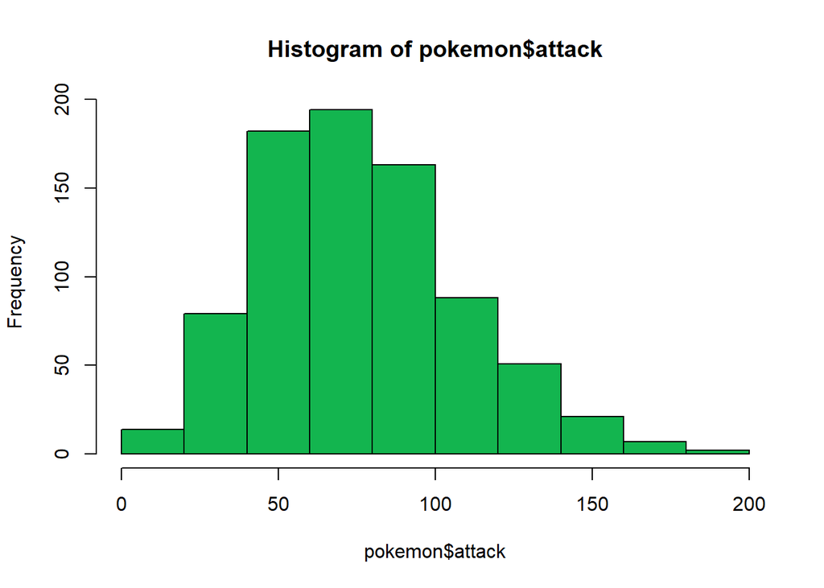

```r
hist(pokemon$attack, col = "#13b54f")
```

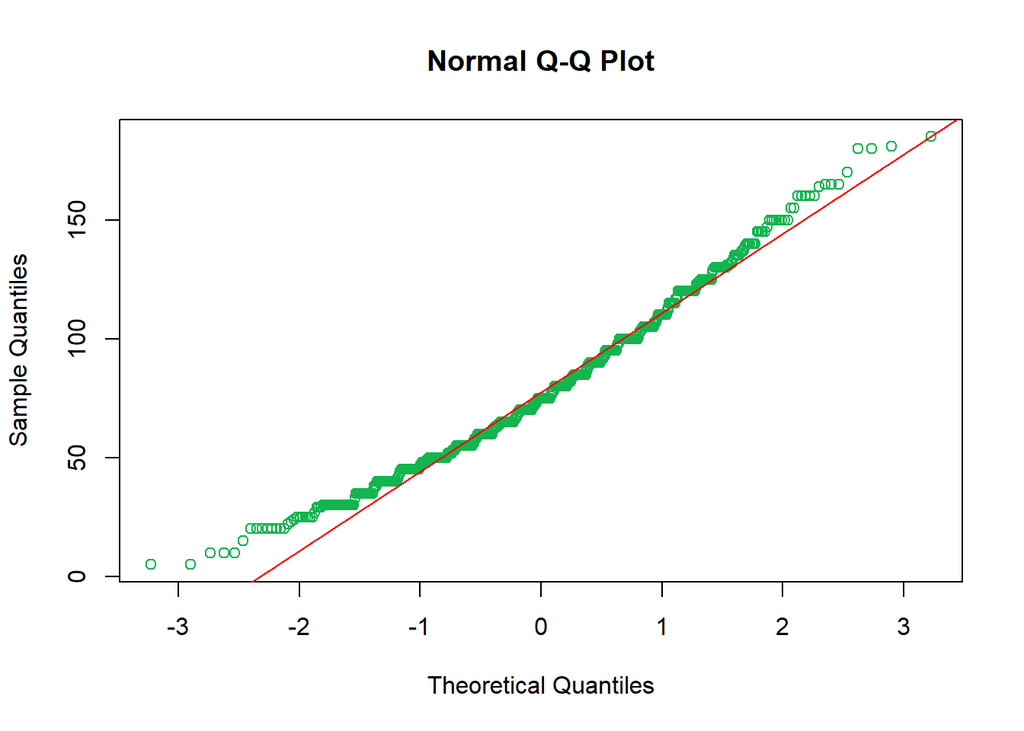

```r
#quntile quantile plot
qqnorm(pokemon$attack, col = "#13b54f")
#qqline for normal distribution
qqline(pokemon$attack,col='red')
```

For each type of height and attack we have the p-value less than 0.05. Hence, we reject our Null Hypothesis (that the data vectors are normally distributed) and conclude that the set of mean values forheight and attack of pokemon is not normally distributed. Thus we cannot use **t test** or **ANOVA** to compare means of our datasets.

Now we will need a non parametric test to compare the means of our datasets pairwise. We will use **Wilcoxon test** to compare the mean.

# Wilcoxon test between defense and attack of pokemon:

- Null Hypothesis, $H_0 :=$ The difference between median value of defense and attack of pokemon is zero.
- Alternate Hypothesis, $H_a :=$ The difference between median value of defense and attack of pokemon is less than zero

```r
wilcox.test(pokemon$defense,pokemon$attack
            ,paired=TRUE,alternative = "less")
```

```
##
##  Wilcoxon signed rank test with continuity correction
##
## data:  pokemon$defense and pokemon$attack
## V = 101335, p-value = 3.01e-08
## alternative hypothesis: true location shift is less than 0
```

Since we get the p-value is less than 0.05 hence we reject our Null hypothesis and get that **median value of defense and attack of pokemon is less than zero.**

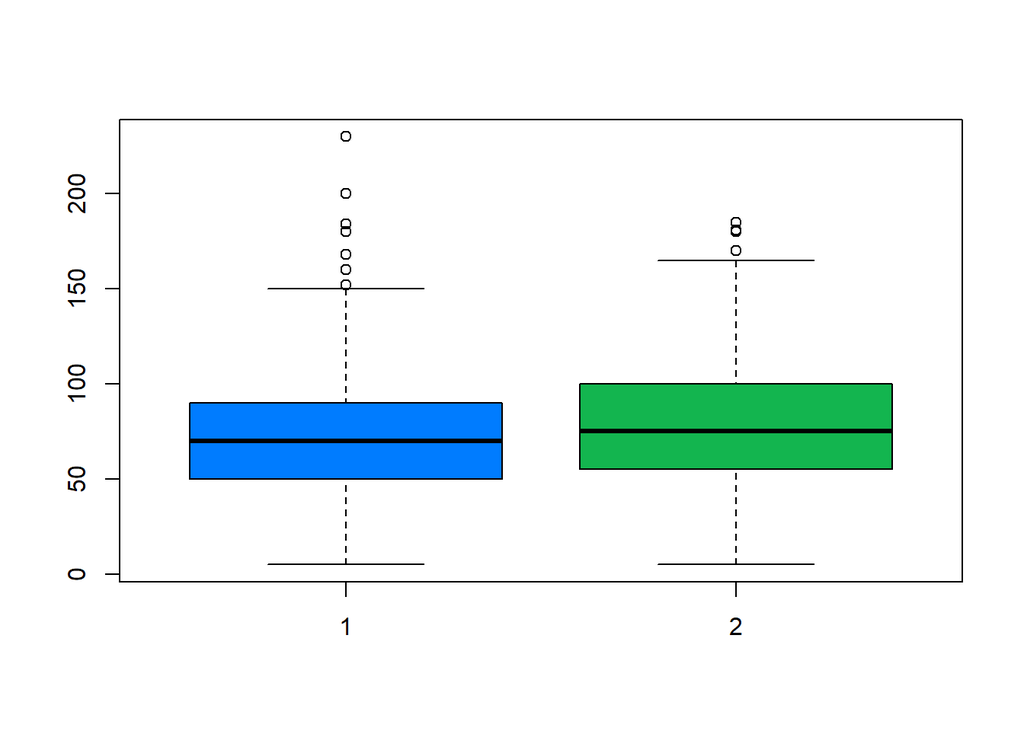

```r
boxplot(pokemon$defense,pokemon$attack
        , col = c("#007cff","#13b54f"))
```

# correlation in attack and defence for pokemon

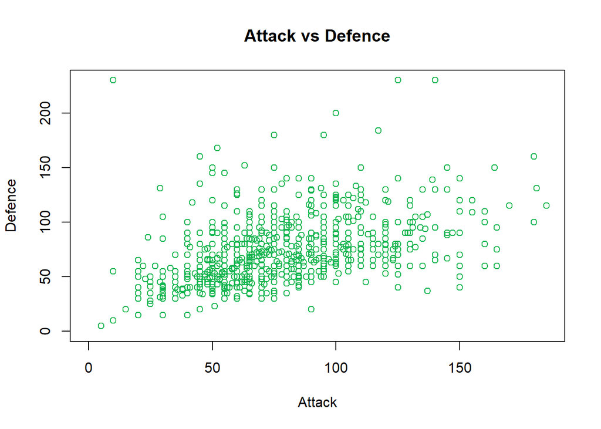

```r
plot(pokemon$attack, pokemon$defense, main="Attack vs Defence", xlab = "Attack", ylab = "Defence", xlim = c(0, max(pokemon$attack)), ylim= c(0, max(pokemon$defense)), col="#13b54f")
```

```r
cor.test(pokemon$defense,pokemon$attack)
```

```
##
##  Pearson's product-moment correlation
##
## data:  pokemon$defense and pokemon$attack
## t = 15.007, df = 799, p-value < 2.2e-16
## alternative hypothesis: true correlation is not equal to 0
## 95 percent confidence interval:
##  0.4130612 0.5212543
## sample estimates:
##       cor
## 0.4689149
```

The attact and defence of pokemon are a bit correlated

### box plot for attack and base total of the pokemon

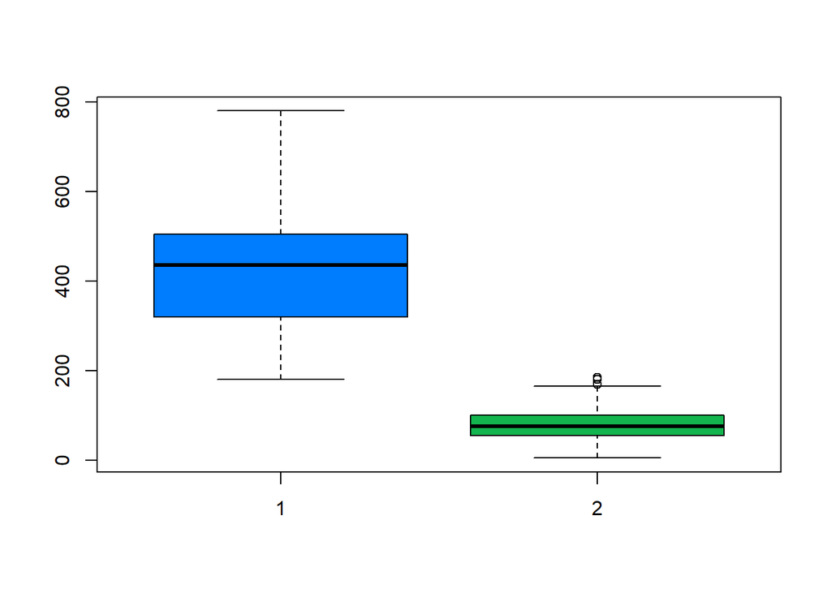

```r
boxplot(pokemon$base_total,pokemon$attack, col = c("#007cff","#13b54f"))
```

## corelation btw attavck and base total

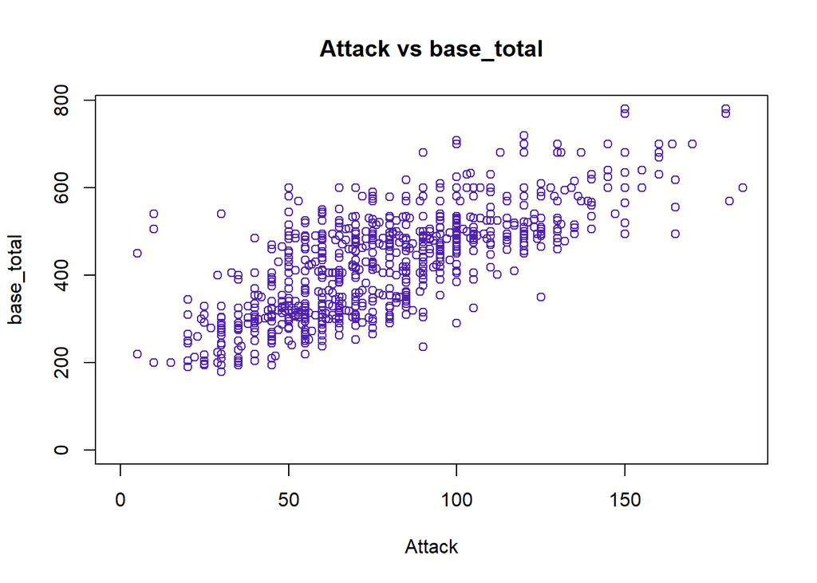

```r
plot(pokemon$attack, pokemon$base_total, main="Attack vs base_total", xlab = "Attack", ylab = "base_total", xlim = c(0, max(pokemon$attack)), ylim= c(0, max(pokemon$base_total)), col="#5122b1")
```

```r
cor.test(pokemon$attack, pokemon$base_total)
```

```
##
##  Pearson's product-moment correlation
##
## data:  pokemon$attack and pokemon$base_total
## t = 30.204, df = 799, p-value < 2.2e-16
## alternative hypothesis: true correlation is not equal to 0
## 95 percent confidence interval:
##  0.6960683 0.7609199
## sample estimates:
##       cor
## 0.7301341
```

The attack and base_total of pokemon are correlated

# histogram plot for all feature vector of pokemon

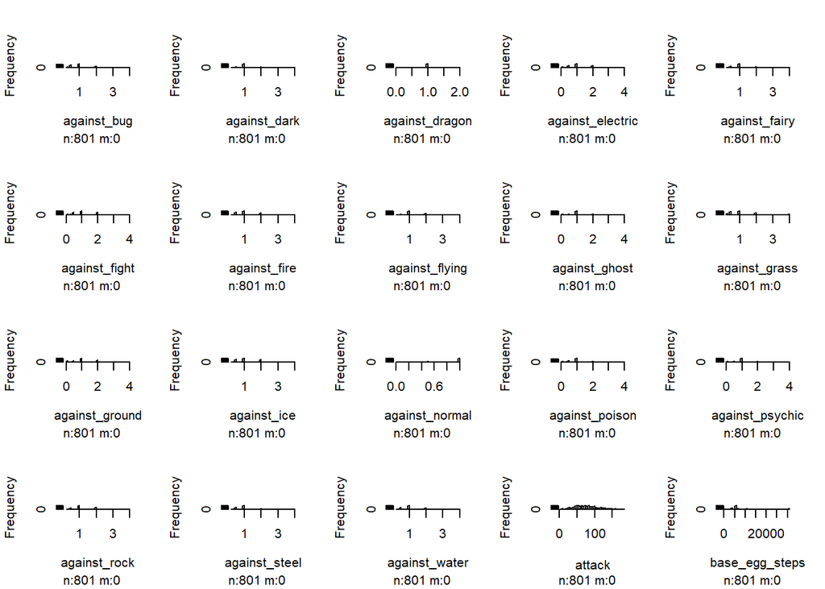

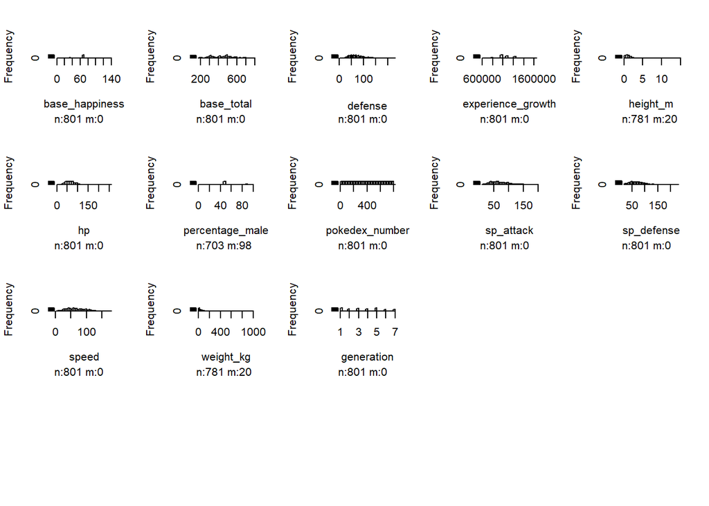

```r
hist.data.frame(num_pokemon, col = c("#007cff","#13b54f"))
```

# hypothesis small pokemon has greater speed

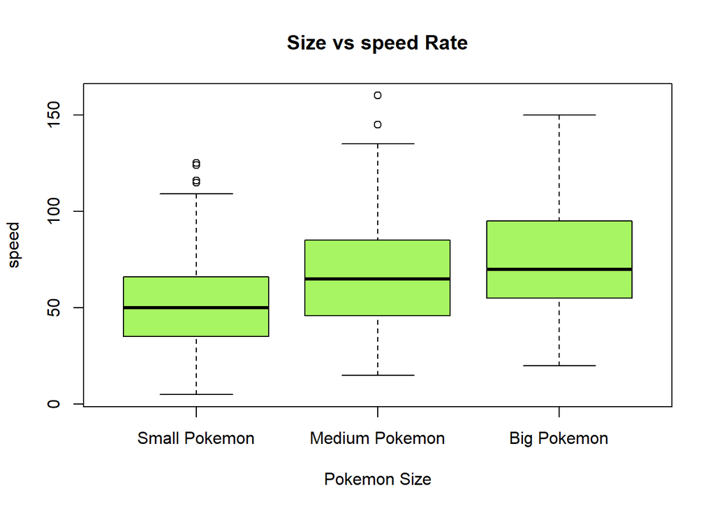

```r
boxplot(as.numeric(small$speed), as.numeric(mid$speed), as.numeric(big$speed),col = "#a7f562", main="Size vs speed Rate", names = c("Small Pokemon", "Medium Pokemon", "Big Pokemon"), xlab="Pokemon Size", ylab="speed")
```

so the speed of big and medium pokemon has greater speed hence my hypothesis is wrong

## normality testing

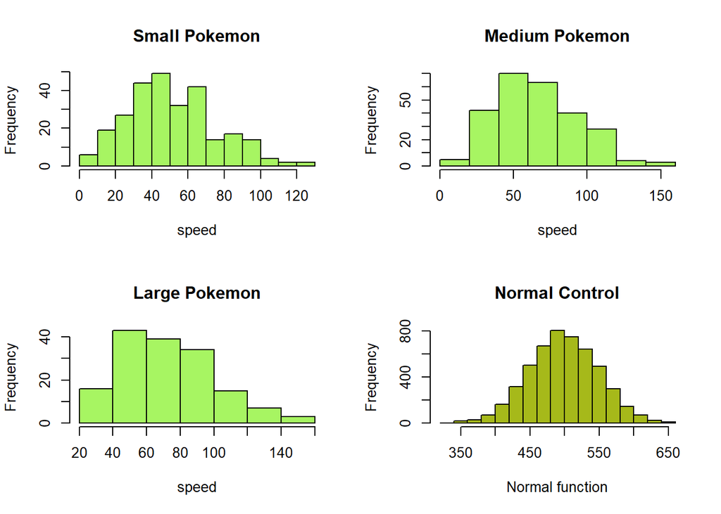

```r
par(mfrow=c(2,2))
hist(as.numeric(small$speed), main = "Small Pokemon", col = "#a7f562", xlab = "speed")
hist(as.numeric(mid$speed), main = "Medium Pokemon", col = "#a7f562", xlab = "speed")
hist(as.numeric(big$speed), main = "Large Pokemon", col = "#a7f562", xlab = "speed")
hist(rnorm(5000,mean=500,sd=50), main = "Normal Control",  col="#A6B91A", xlab = "Normal function")
```

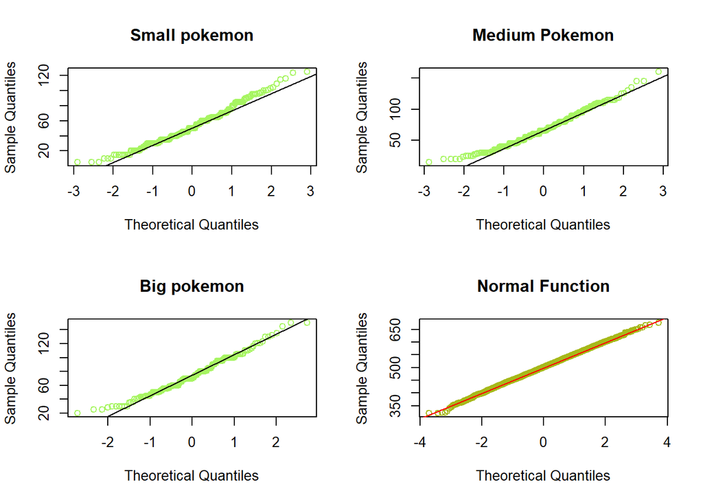

```r
par(mfrow=c(2,2))
qqnorm(as.numeric(small$speed), col = "#a7f562", main = "Small pokemon" )
qqline(as.numeric(small$speed))

qqnorm(as.numeric(mid$speed), col="#a7f562", main = "Medium Pokemon")
qqline(as.numeric(mid$speed))

qqnorm(as.numeric(big$speed), col = "#a7f562", main = "Big pokemon")
qqline(as.numeric(big$speed))

qqnorm(rnorm(5000,mean=500,sd=50),  col="#A6B91A", main = "Normal Function")
qqline(rnorm(5000,mean=500,sd=50), col= "red")
```